# Práctica 3 — Procesamiento Digital de Imágenes

### Explicaciones del Ejercicio 3

**Descripción:**

En este ejercicio hay que utilizar un generador de ruido uniforme y probar el filtro de mediana con distintos valores de radio y porcentajes de ruido, en tonos de gris y en RGB, para ver si existe una relación entre el porcentaje de ruido y la máscara del filtro.

Para empezar, se usan dos amplitudes: 0.05 y 0.20. Como son muchas imágenes generadas, mejor nos quedamos con esas dos amplitudes y dos tamaños de kernel: 3 y 5. Hay que tener cuidado de que el tamaño sea impar.

Todo esto se está aplicando sobre la imagen del golf, que es bastante buena para esto porque tiene muchos colores y también funciona bien en tonos de gris.

**¿Es posible establecer una relación entre porcentaje de ruido y radio de máscara?**

No podemos decir exactamente que existe una relación tal cual, pero sí podemos ver algo. Aunque el ruido junto con la mediana se aplique de cierta forma, sí se nota un patrón.

¿Dónde se nota? Cuando los valores son similares, sin importar si es gris o color, con la misma mediana y el mismo ruido uniforme aplicado. Es ahí donde sí se ve un patrón, no tanto entre los demás casos, pero sí existe una cierta escala.

Es curioso cómo se afecta. También hay que tener algo en cuenta: el ruido se aplica con una semilla específica para poderlo reproducir. Entonces no está totalmente al azar, sino que la semilla está apoyando en algo. Quizás por eso se distingue un poco mejor el patrón en este sentido.

## 4️⃣ — Ejercicio 4

Utilizando la tecnica **High-Boost**, en conjunto con los ajustes de contraste y ecualizacion probados anteriormente, busque un mejor resultado para el tratamiento de la radiografia. Pruebe ajustar primero el contraste seguido del filtrado, asi como filtrado primero y terminar con ajuste de contraste. ¿Hay alguna diferencia en el orden?

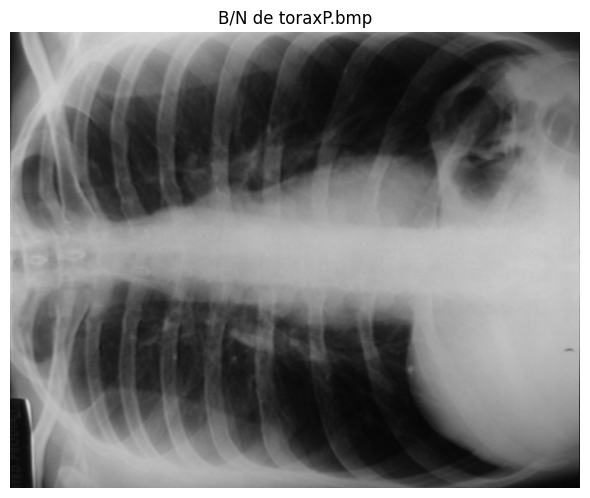

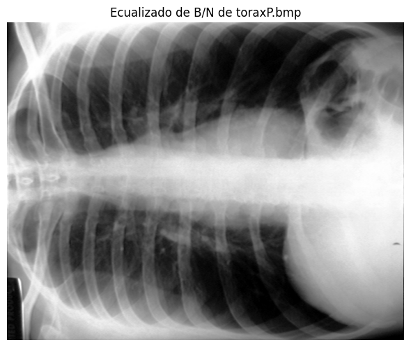

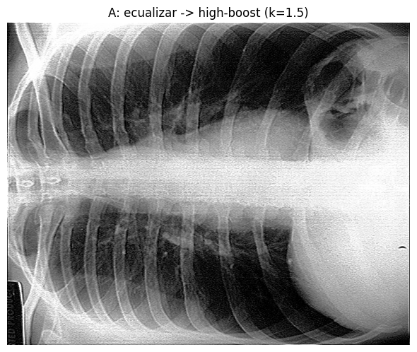

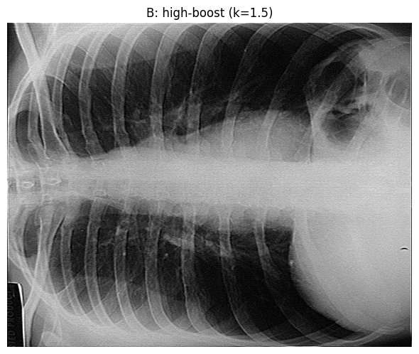

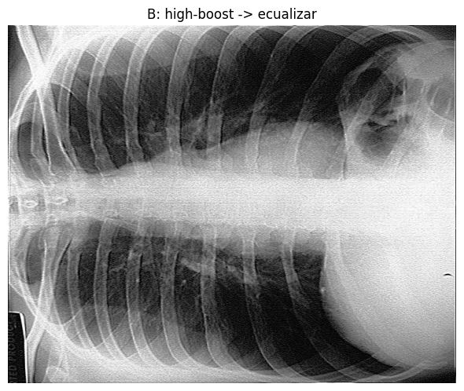

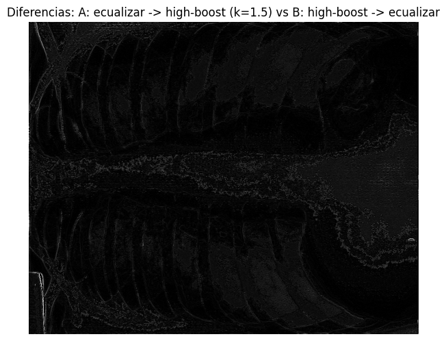

```python
imagen_torax = load_image("torax").escala_grises()
imagen_torax.mostrar(block=False)

k = 1.5

ajustada_A = imagen_torax.ecualizar()
ajustada_A.mostrar(block=False)

lap_A = ajustada_A.laplaciano(extendido=True, crudo=True)
resultado_A = (ajustada_A - lap_A * k).clip()
resultado_A.title = f"A: ecualizar -> high-boost (k={k})"
resultado_A.mostrar(block=False)

lap_B = imagen_torax.laplaciano(extendido=True, crudo=True)
boost_B = (imagen_torax - lap_B * k).clip()
boost_B.title = f"B: high-boost (k={k})"
boost_B.mostrar(block=False)

resultado_B = boost_B.ecualizar()
resultado_B.title = "B: high-boost -> ecualizar"
resultado_B.mostrar(block=False)

resultado_A.mostrar_diferencias(resultado_B, magnifier=3.0, block=False)

plt.show()
```

### Explicaciones del Ejercicio 4

**Descripción:**

El ejercicio 4 consiste en aplicar diferentes ecualizaciones a una radiografía del tórax, junto con el high-boost, que nos ayuda a marcar los bordes y las diferencias.

**¿Hay alguna diferencia en el orden (contraste → filtrado vs filtrado → contraste)?**

Sí, hay diferencias. Probamos los dos órdenes:

Si primero ecualizamos y después aplicamos el high-boost, tenemos un resultado bastante bueno, donde sí podemos resaltar y ver cosas. Pero no es broma que también podemos ver ruido en la imagen, un cierto patrón un poco granular donde se ven los bordes.

Si lo aplicamos al revés, primero el high-boost y después la ecualización, es un poquito diferente, pero la verdad es que el resultado se parece bastante a lo que pasa cuando se aplica una reducción de bits. Es decir, se ven como segmentos o manchas donde se va perdiendo la definición o la gama de colores. Como cuando en vez de tener 32 niveles, se reduce a 16 o a 8.

Si hacemos la resta de las diferencias entre los dos resultados, podemos ver el cambio. La verdad no está tan padre como se esperaría. Entre los dos resultados, visualmente, realmente no hay una diferencia tan grande. Es un poco chistoso porque, en teoría, los filtros no son conmutativos (el orden sí afecta el resultado final), pero en la práctica el resultado visual no se nota tan diferente. Sin embargo, sí hay diferencias, y la resta entre los dos lo muestra claramente.

Como conclusión: el orden de los factores sí afecta el producto final. No son conmutativos, aunque a simple vista lo parezca.

## 5️⃣ — Ejercicio 5

Elija una fotografia para aplicar la tecnica de deteccion de bordes. El resultado del procesamiento debe parecer el trazado en blanco y negro del perfil de los objetos.

[figure not shown]

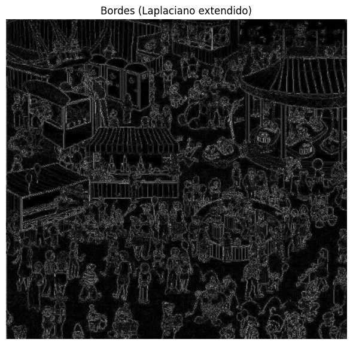

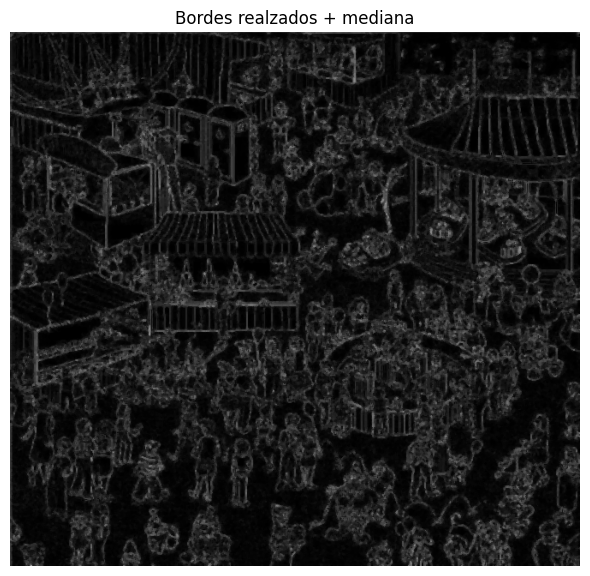

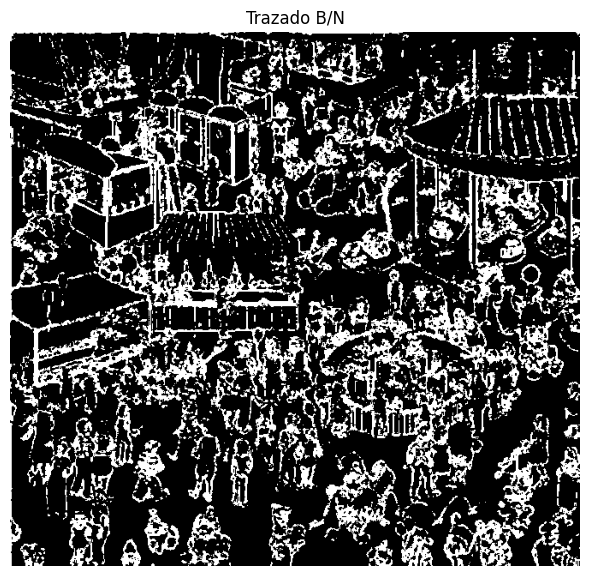

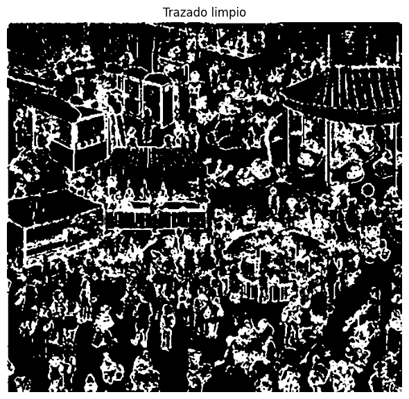

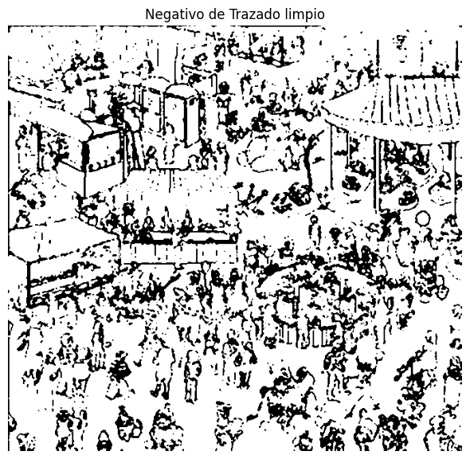

```python
imagen = load_image("waldo").escala_grises()
imagen.mostrar(block=False)

bordes = imagen.laplaciano(extendido=True)
bordes.title = "Bordes (Laplaciano extendido)"
bordes.mostrar(block=False)

bordes_realzados = bordes.estirar_contraste()
suavizado = bordes_realzados.mediana(size=3)
suavizado.title = "Bordes realzados + mediana"
suavizado.mostrar(block=False)

trazado = suavizado.binarizar(0.15)
trazado.title = "Trazado B/N"
trazado.mostrar(block=False)

trazado_limpio = trazado.mediana(size=3)
trazado_limpio.title = "Trazado limpio"
trazado_limpio.mostrar(block=False)

trazado_limpio.negativo().mostrar(block=False)

plt.show()
```

### Explicaciones del Ejercicio 5

**Descripción:**

Se eligió la foto del escenario con muchas personitas (Waldo). Es bastante buena para este ejercicio porque es una figura tipo dibujo animado, donde podemos resaltar muchos colores y píxeles.

Primero la pasamos a blanco y negro, es decir, a tonos de gris. Después se aplicó un laplaciano con sus 8 vecinos. Cuando hablo de 8 vecinos, me refiero a que también se están tomando las diagonales. La librería que armé ayuda justamente a que el laplaciano no actúe solo como una máscara de cruz, sino que sea un "doble laplaciano" que también aplica sobre las esquinas.

**Pipeline aplicado y resultados:**

En teoría, si aplicamos un poquito de filtros uno tras otro, es decir, un laplaciano y luego una mediana, puede ayudar un poquito. Lo que se hizo fue: aplicar el laplaciano, estirar un poquito el contraste para poder ver bien los valores de los píxeles, aplicar una mediana, y luego binarizar.

¿Por qué una mediana? La intuición era que con este pipeline mejoraríamos el resultado, suavizando los valores que saca el laplaciano de los bordes (porque la mediana es buena para limpiar) y luego binarizar. En teoría, al menos, sería genial.

¿Cuál es el problema? Que la mediana con kernel de 3 suaviza al punto donde se pierde la definición de muchas figuras. Una vez que llegamos al binarizado para forzar los bordes, ahí sí se pierde por completo.

Si me preguntas si hay mejora entre el laplaciano solo y el laplaciano más mediana, de alguna manera sí se pierde un poco el brillo. La definición no es la mejor, parece un poco borrosa, pero de alguna manera se mantiene bastante bien.

Considero que el laplaciano por sí solo ya es bastante bueno en este sentido. Si se quiere hacer un binarizado para tener un trazado en blanco y negro tal cual, está un poco difícil. Se intentó aplicarle al binarizado una mediana al final, para ver si limpiaba el ruido blanco que se podía estar generando. En teoría debería mejorar y dejar todo más limpio. El problema es que no precisamente: si se aplica un kernel mucho más grande, empieza a borrarse aún más la definición de los píxeles que ya estaban binarizados. Solo para poder distinguir mejor, le aplicamos un negativo para ver cómo se vería.

Pero en realidad no funciona muy bien para todo lo que se planeaba hacer. Creo que con el laplaciano para definir bordes es suficiente, porque más allá de eso, lo que se hizo no implicó otro esfuerzo de reordenar cómo se están aplicando los filtros. Por ejemplo, podría intentarse después del laplaciano aplicar directamente el binarizado, sin tantos pasos intermedios. No estaría mal, funciona, pero al final esta práctica es para visualizar qué cambia y no hay recetas específicas. De alguna manera, se obtuvo un resultado con todo esto.

## 6️⃣ — Ejercicio 6

En la carpeta **FIBRA** hay multiples imagenes de una fibra optica dopada con Erbio cuyo nucleo brilla en color verde cuando se bombea con un diodo laser de 1500 nm. Estas imagenes fueron tomadas en condiciones de baja iluminacion y con una camara que era particularmente ruidosa. Realice la **resta entre dos imagenes consecutivas** para evaluar el ruido. Puede usar el histograma para revisar si el ruido tiene una distribucion normal.

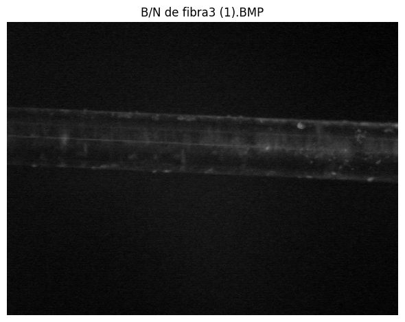

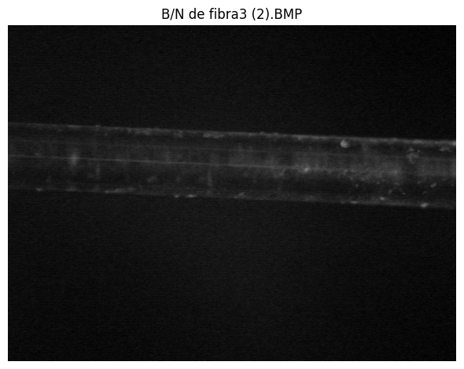

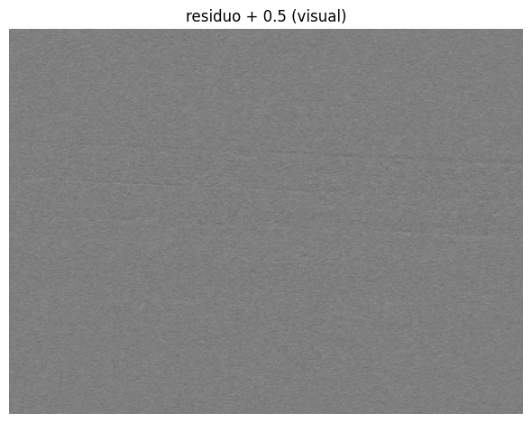

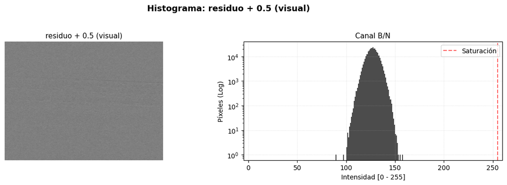

```
media=-0.0013, std=0.0220
```

```python
fibras = load_fibras(11)
fibra_a = fibras[0].escala_grises()
fibra_b = fibras[1].escala_grises()
fibra_a.mostrar(block=False)
fibra_b.mostrar(block=False)

residuo_centrado = (fibra_a - fibra_b + 0.5).clip()
residuo_centrado.title = "residuo + 0.5 (visual)"
residuo_centrado.mostrar(block=False)
residuo_centrado.histograma(block=False)

residuo_t = (fibra_a.tensor - fibra_b.tensor)
print(f"media={residuo_t.mean():.4f}, std={residuo_t.std():.4f}")

plt.show()
```

### Explicaciones del Ejercicio 6

**Descripción:**

En este ejercicio tenemos múltiples imágenes de la fibra, y lo que buscamos es revisar el ruido haciendo una resta entre dos de ellas. Subimos un poco la gama para que podamos ver un tono de gris y notar cuáles son las diferencias marcadas. En efecto, sí se alcanza a ver un ruido.

De hecho, esta técnica fue parte de una pregunta que le hice al profesor en clase: ¿qué pasa si no tenemos dos imágenes para comparar? ¿Qué hacemos en ese caso? Porque al final de cuentas, en este ejercicio en particular sí estamos comparando dos fibras que existen.

Como dijo el profesor: si tomamos dos fotos consecutivamente, vamos a poder ver la varianza entre los píxeles y notar el ruido que existe entre una toma y la otra. Esto sí es una afectación real al resultado cuando se está haciendo procesamiento de imagen, así que sí necesitamos contemplarlo en diferentes escenarios. Es interesante y curioso.

**¿El ruido tiene distribución normal?**

Sí, sí se puede ver cómo existe una distribución normal al momento de revisar el ruido. Es curioso, pero es real, y es una buena estrategia cuando se tiene la capacidad de contar con dos imágenes.

Ahora, esto aplica solo cuando se tienen dos. Cuando solo se tiene una, la estrategia es diferente. Pero la idea respecto a esto es interesante y también nos dice mucho de la cámara: las cámaras tienen una varianza natural, un ruido propio que aparece por cómo funcionan los fotones en sus sensores. No siempre reciben la misma cantidad de luz, y es importante tenerlo muy en cuenta al hacer procesamiento de imagen.

## 7️⃣ — Ejercicio 7

Otra forma de reducir el ruido sin atenuar las altas frecuencias es **promediar imagenes consecutivas**. Esta tecnica se usa frecuentemente en Astronomia. Promedie 11 imagenes consecutivas de la fibra y compare el resultado con la imagen original. ¿Puede apreciar la reduccion del ruido?

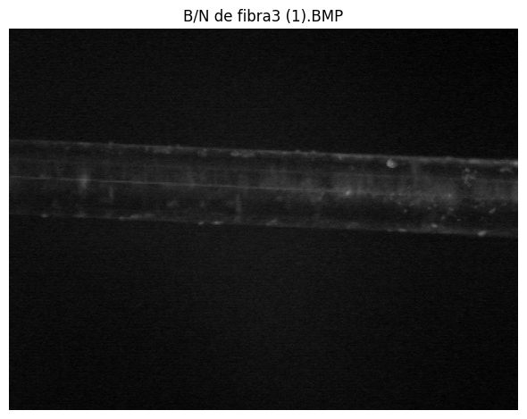

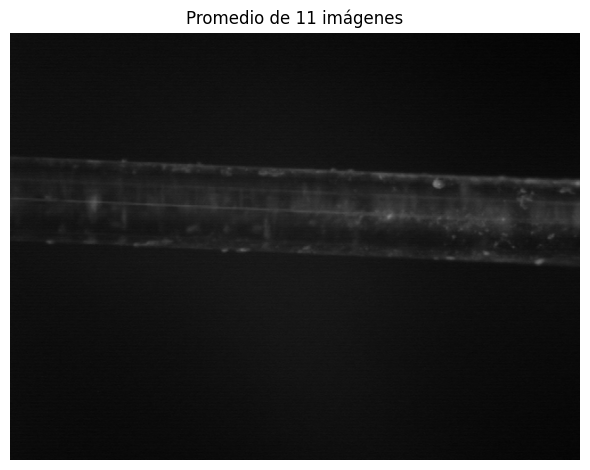

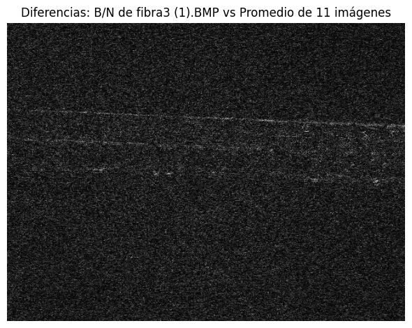

```
σ_original=0.0220, σ_promedio=0.0150
reduccion ≈ 1.47x  (teorica √11 ≈ 3.32x)
```

```python
fibras = [f.escala_grises() for f in load_fibras(11)]
fibras[0].mostrar(block=False)

promedio = fibras[0].promediar(fibras[1:])
promedio.mostrar(block=False)

fibras[0].mostrar_diferencias(promedio, magnifier=10.0, block=False)

ruido_original = (fibras[0].tensor - fibras[1].tensor).std().item()
ruido_promedio = (promedio.tensor - fibras[5].tensor).std().item()
reduccion = ruido_original / ruido_promedio
print(f"σ_original={ruido_original:.4f}, σ_promedio={ruido_promedio:.4f}")
print(f"reduccion ≈ {reduccion:.2f}x  (teorica √11 ≈ 3.32x)")

plt.show()
```

### Explicaciones del Ejercicio 7

**Descripción:**

Otra forma de reducir el ruido, sin atenuar las altas frecuencias, es promediar imágenes consecutivas. Esta técnica se usa frecuentemente en astronomía. Aquí lo que se hace es promediar 11 imágenes consecutivas de la fibra y comparar el resultado con la imagen original.

**¿Se puede apreciar la reducción del ruido?**

Sí, sí se puede. Y es interesante porque, si bien lo que se está haciendo en este ejercicio parecería muy evidente, tiene sus sutilezas.

Si estamos hablando de que tenemos 11 muestras de imágenes, partimos de la premisa del ejercicio anterior: tener un punto de comparación o referencia con muestras viejas que involucren otros datos diferentes, aunque sea de manera mínima. Es decir, cuando dejamos una cámara corriendo en vivo, podemos notar, al hacer un zoom suficiente, cómo los valores de los píxeles varían por muy mínimo que sea. Y es curioso cómo lo hacen.

Esto nos muestra cómo se comportan algunos segmentos. No siempre se logra distinguir esta afectación de una manera brutal, pero sí pasa, sí existe.

Es importante aclarar que estas 11 imágenes, integradas haciendo un promedio, sí muestran una afectación final y real. De hecho, el ruido que se puede notar de las 11 muestras al momento de hacer la comparación o la resta es curioso. Parecería que no es tanto, pero en realidad sí lo es.

**El factor de reducción:**

Para empezar, existe un factor teórico: es la raíz cuadrada de 11, que es aproximadamente 3.32. En el caso real medido, vemos una reducción de alrededor de 1.4 entre la original y el promedio en cuanto a la desviación estándar. Eso nos dice bastante información sobre el ruido involucrado.

¿Se puede reducir esto? Totalmente. Es interesante cómo, gracias a este análisis, podemos aplicar una limpieza de ruido con una distribución estándar ya prefabricada a partir de las imágenes que tenemos.

## Conclusiones

Lo que más llamó la atención de toda la práctica es que cada filtro tiene sus condiciones para funcionar bien, y es muy fácil pensar que aplicando uno en cualquier momento se va a resolver el problema, pero no es así. La mediana, por ejemplo, es buenísima contra sal y pimienta porque trabaja con la moda local de los píxeles, pero si la aplicas con un kernel grande también te empieza a borrar la definición de lo que sí querías conservar. Lo mismo pasa con el high-boost: el orden en que lo combinas con la ecualización sí cambia el resultado, aunque a simple vista a veces no se note tanto.

En la parte del laplaciano para detección de bordes, lo curioso es que aplicarlo solo ya da un resultado bastante bueno; los pasos extra de mediana o binarizado pueden ayudar, pero también pueden estropear la definición si uno se pasa con el tamaño del kernel.

Los ejercicios de la fibra fueron quizá los más interesantes desde el punto de vista práctico: poder evaluar el ruido de una cámara con la resta entre dos tomas consecutivas, y reducir ese mismo ruido promediando muchas imágenes, son técnicas que se ven simples pero tienen mucho fondo (la teoría del raíz de N, la distribución normal del ruido, etc.).

Al final, la práctica deja claro que no hay recetas universales: depende mucho de qué imagen se está tratando, qué tipo de ruido tiene y qué se busca conservar. El histograma siempre es la herramienta clave para decidir qué técnica aplicar antes de meterse a probar a ciegas.